# Covid19: Causal Analysis & Search Trends

Florian Endel

2025-01-26

# Exploratory Data Analysis

## Demographic Variables

### Age Distribution

| Mean | Median | SD | Min | Max |
| --- | --- | --- | --- | --- |
| 41.79 | 40 | 16.91 | 0 | 121 |

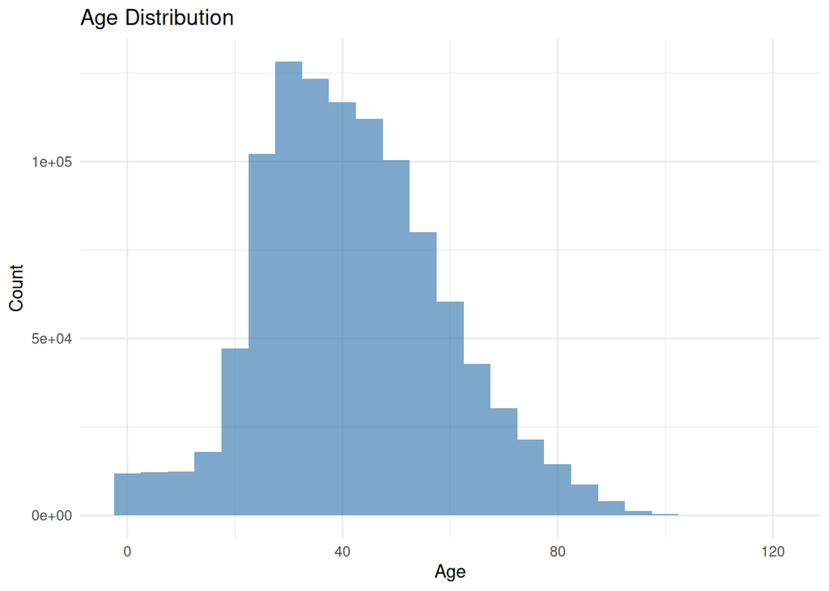

### Sex Distribution

Distribution of SEX

| SEX | Count | Percentage |
| --- | --- | --- |
| female | 525064 | 50.07 |
| male | 523511 | 49.93 |

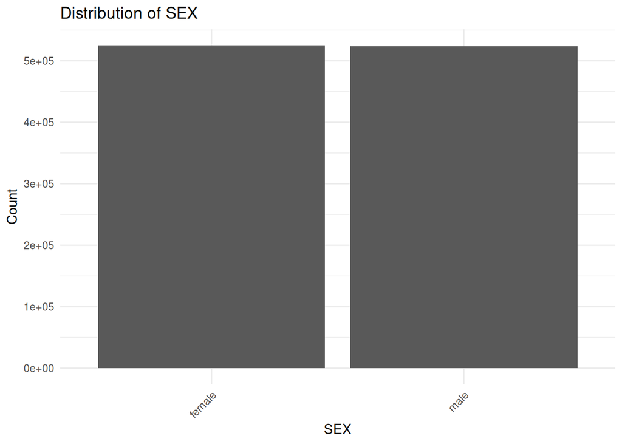

## Medical Conditions

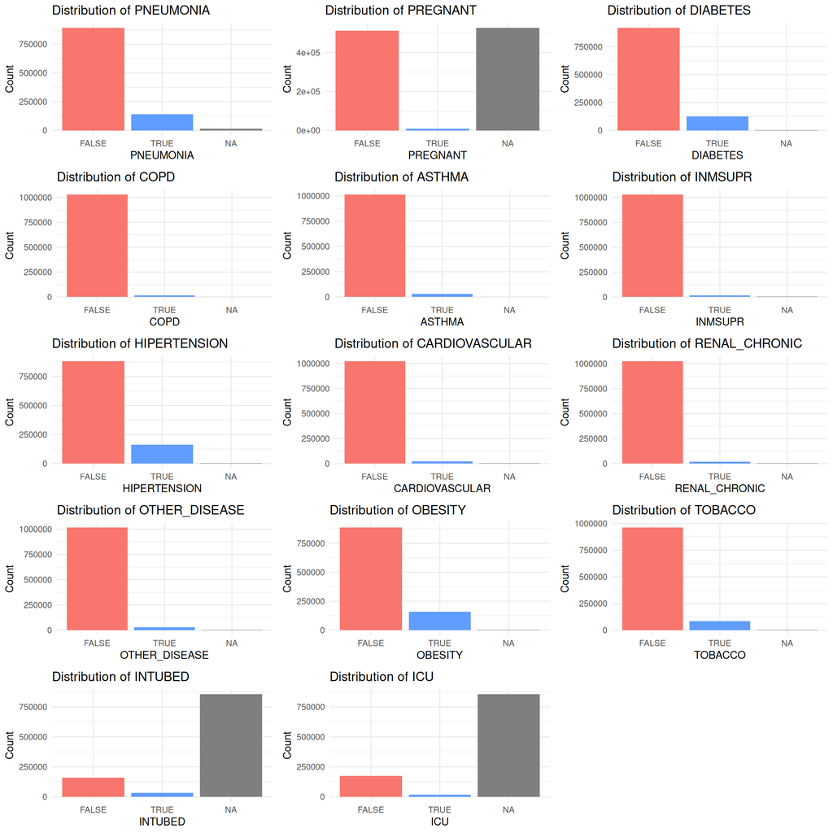

## Patient Management

Distribution of PATIENT_TYPE

| PATIENT_TYPE | Count | Percentage |
| --- | --- | --- |
| hospitalization | 200031 | 19.08 |
| returned home | 848544 | 80.92 |

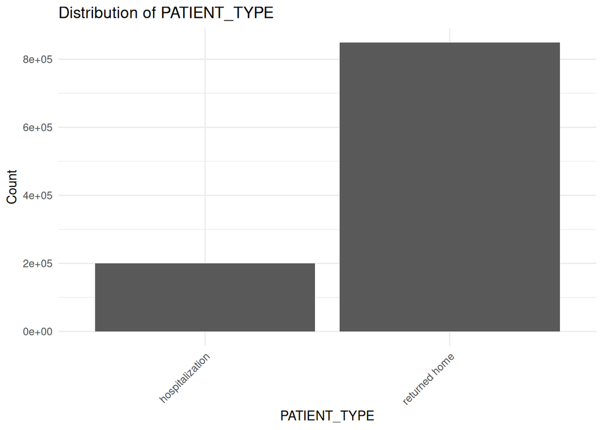

## COVID-19 Classification

classification: covid test findings. Values 1-3 mean that the patient was diagnosed with covid in different degrees. 4 or higher means that the patient is not a carrier of covid or that the test is inconclusive.

| CLASIFFICATION_FINAL | n | Percentage |
| --- | --- | --- |
| 1 | 8601 | 0.8202561 |
| 2 | 1851 | 0.1765253 |
| 3 | 381527 | 36.3852848 |
| 4 | 3122 | 0.2977374 |
| 5 | 26091 | 2.4882340 |
| 6 | 128133 | 12.2197268 |
| 7 | 499250 | 47.6122357 |

### Overall Testing Summary

Overall COVID-19 Testing Summary

| Total Cases | Tested Positive | Tested Negative | Positive Rate (%) |
| --- | --- | --- | --- |
| 1048575 | 391979 | 656596 | 37.38 |

### Detailed Classification Distribution

| Classification | Count | Percentage | Meaning |
| --- | --- | --- | --- |
| 1 | 8601 | 0.82 | COVID-19 Positive Degree 1 |
| 2 | 1851 | 0.18 | COVID-19 Positive Degree 2 |
| 3 | 381527 | 36.39 | COVID-19 Positive Degree 3 |
| 4 | 3122 | 0.30 | Negative or Inconclusive |
| 5 | 26091 | 2.49 | Negative or Inconclusive |
| 6 | 128133 | 12.22 | Negative or Inconclusive |
| 7 | 499250 | 47.61 | Negative or Inconclusive |

### Visual Distribution of Test Results

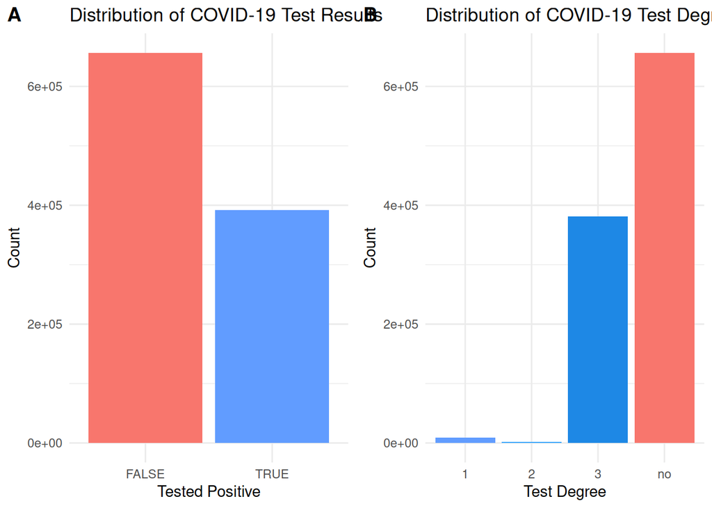

# Causal Analysis with DAGs

In this section, we explore the causal relationships between different factors and COVID-19 outcomes. We use Directed Acyclic Graphs (DAGs) to formalize our causal assumptions and guide our analysis.

## DAG Specification and Initial Analysis

First, we create a DAG representing our hypothesized causal relationships. This graph shows how different medical conditions and demographic factors might influence COVID-19 mortality.

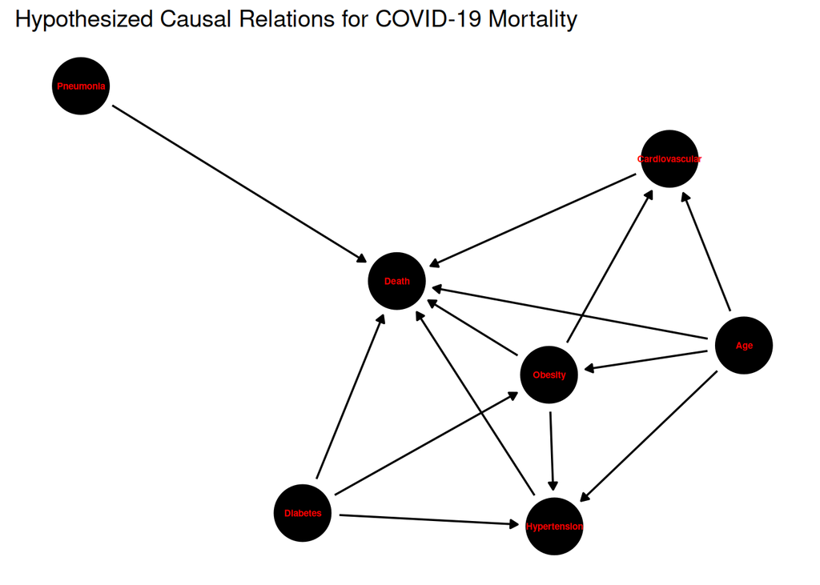

The DAG reveals several pathways through which obesity may affect mortality: - Direct effect: Obesity -> Death - Via cardiovascular system: Obesity -> Cardiovascular -> Death - Via blood pressure: Obesity -> Hypertension -> Death This multiple-pathway structure explains why controlling for mediators (like hypertension) is expected to reduce the total estimated effect.

## Identifying Causal Paths and Adjustment Sets

Next, we examine the paths between key variables and identify proper adjustment sets for causal estimation.

All Paths from Obesity to Death

[output not shown]

Minimal Adjustment Sets for Estimating Obesity’s Effect on Death

| Adjustment Set |
| --- |
| Age, Diabetes |

The DAG analysis identifies that we need to adjust for **Age** and **Diabetes** to estimate the causal effect of obesity on mortality. This means:

1. Age and diabetes are confounders - they affect both obesity and death risk independently
2. Without adjusting for these variables, our estimate of obesity’s effect on death would be biased
3. After adjusting for age and diabetes, any remaining association between obesity and death can be interpreted more causally

This suggests that in our statistical analyses, we should always control for age and diabetes when estimating the effect of obesity on COVID-19 mortality. Other variables like hypertension and cardiovascular disease are potential mediators (they lie on the causal pathway between obesity and death) and should not be adjusted for if we want to estimate the total causal effect of obesity.

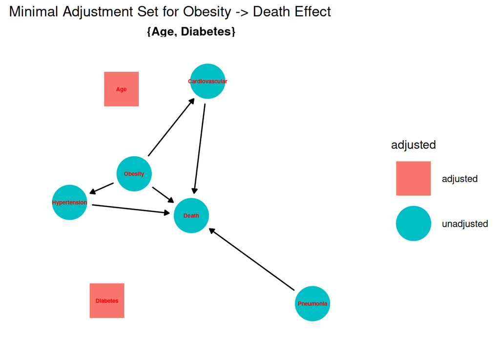

## Testing DAG Implications with Data

Now we’ll test whether our data is consistent with the causal assumptions encoded in our DAG.

Tests of Conditional Independence

| Variable | Estimate | P-value |
| --- | --- | --- |
| Obesity | 0.384 | 0 |
| Hypertension | 0.471 | 0 |

The test results show significant associations (p < 0.001) between:

1. Obesity and Death, even after adjusting for Age and Diabetes, supporting a causal relationship
2. Hypertension and Death, even after adjusting for Age and Obesity, suggesting an independent effect

These results are consistent with our DAG’s structure.

## Estimating Causal Effects

Based on the adjustment sets identified by our DAG, we estimate the causal effect of obesity on mortality.

Estimated Causal Effect of Obesity on Mortality

| model | estimate | std.error | p.value | OR | CI_lower | CI_upper |
| --- | --- | --- | --- | --- | --- | --- |
| DAG-based (correct adjustment) | 0.384 | 0.01 | 0 | 1.467 | 1.439 | 1.497 |
| With mediator (over-adjusted) | 0.343 | 0.01 | 0 | 1.410 | 1.382 | 1.438 |

## Interpretation

The DAG-based analysis shows that obesity has a significant causal effect on COVID-19 mortality. The properly adjusted model (controlling for age and diabetes) indicates that obesity increases the odds of death by 47% (OR = 1.47, 95% CI: 1.44-1.50).

When we additionally control for hypertension (a mediator), the estimated effect decreases to 41% (OR = 1.41, 95% CI: 1.38-1.44). This reduction is expected because we’re blocking one of the pathways through which obesity affects mortality (via hypertension), thus capturing only part of obesity’s total causal effect.

This analysis suggests that obesity has both direct effects on COVID-19 mortality and indirect effects through conditions like hypertension. For public health purposes, the larger total effect (47% increased odds) is most relevant, as it captures the full impact of obesity on COVID-19 mortality risk.

The DAG analysis reveals several important insights:

1. Obesity affects mortality both directly and through multiple indirect paths (via Hypertension and Cardiovascular disease).
2. Age is a key confounder that needs to be adjusted for in any analysis.
3. Different adjustment sets lead to somewhat different effect estimates, highlighting the importance of careful consideration of causal pathways.

## Limitations

This causal analysis has several limitations: - The DAG represents our assumptions about causal relationships but cannot prove causality. - We assume no unmeasured confounding. - The relationships are likely more complex than shown in our simplified DAG. - Missing data and measurement error could bias our estimates.

# Google Trends Analysis

To complement our analysis of COVID-19 cases in Mexico, we examine Google search trends that might reflect public interest and concern about the pandemic. We compare search patterns with actual mortality data to understand the relationship between public attention and health outcomes.

## Data Processing

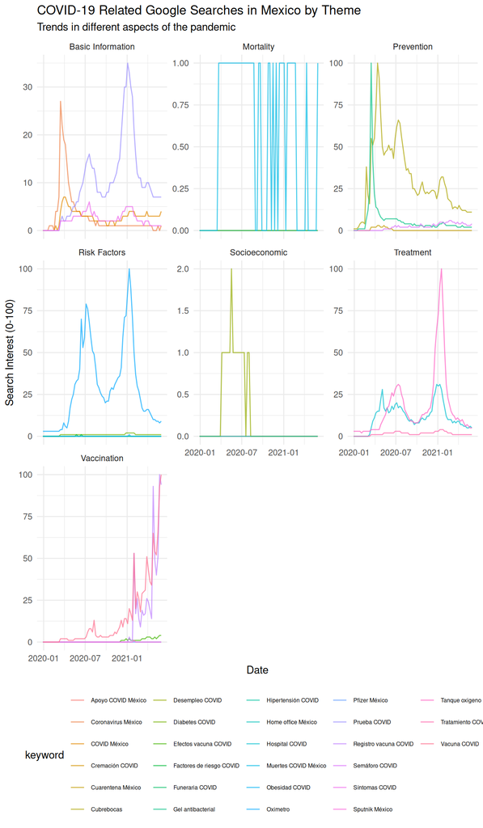

## Comparison of Search Trends and Mortality

Temporal pattern of COVID-19 deaths in Mexico:

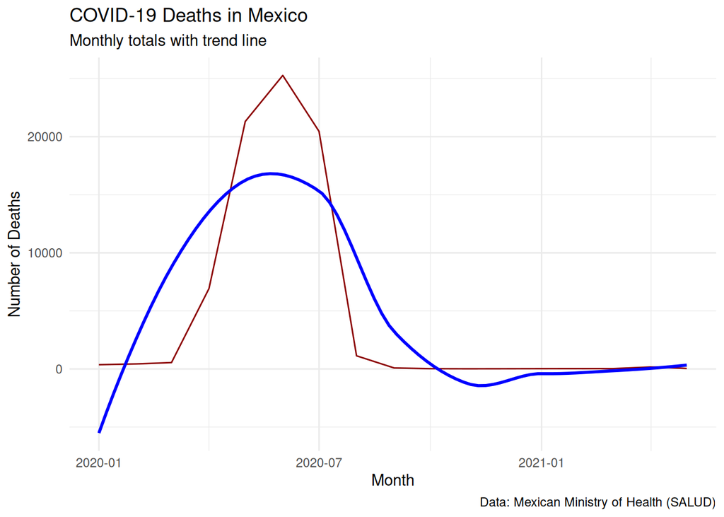

Google search trends:

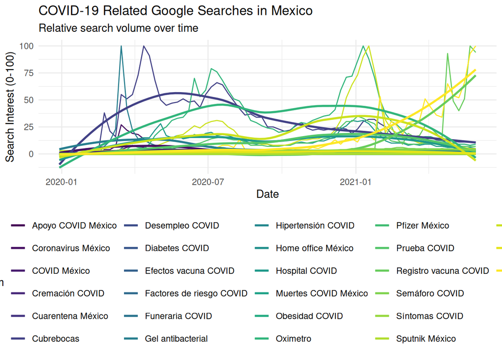

## Correlation Analysis

We can examine the relationship between search interest and mortality:

Correlations between Search Interest and COVID-19 Deaths

| Search Term (Spanish) | Search Term (English) | Correlation | P-value | Significance |
| --- | --- | --- | --- | --- |
| Desempleo COVID | COVID unemployment | 0.900 | 0.000 | *** |
| Factores de riesgo COVID | COVID risk factors | 0.815 | 0.000 | *** |
| Muertes COVID México | COVID deaths Mexico | 0.635 | 0.006 | ** |
| Cubrebocas | Face masks | 0.632 | 0.006 | ** |
| Síntomas COVID | COVID symptoms | 0.464 | 0.060 | ns |
| Cuarentena México | Quarantine Mexico | 0.417 | 0.096 | ns |
| Hospital COVID | COVID hospital | 0.416 | 0.097 | ns |
| Oximetro | Oximeter | 0.393 | 0.119 | ns |
| Efectos vacuna COVID | COVID vaccine side effects | -0.345 | 0.175 | ns |
| COVID México | COVID Mexico | 0.337 | 0.186 | ns |
| Tratamiento COVID | COVID treatment | 0.322 | 0.207 | ns |
| Vacuna COVID | COVID vaccine | -0.305 | 0.233 | ns |
| Registro vacuna COVID | COVID vaccine registration | -0.267 | 0.301 | ns |
| Semáforo COVID | COVID traffic light system | -0.249 | 0.336 | ns |
| Coronavirus México | Coronavirus Mexico | 0.178 | 0.494 | ns |
| Obesidad COVID | COVID obesity | -0.133 | 0.611 | ns |
| Sputnik México | Sputnik Mexico | -0.133 | 0.611 | ns |
| Tanque oxigeno | Oxygen tank | 0.085 | 0.746 | ns |
| Diabetes COVID | COVID diabetes | 0.068 | 0.795 | ns |
| Gel antibacterial | Hand sanitizer | 0.066 | 0.802 | ns |
| Prueba COVID | COVID test | -0.049 | 0.852 | ns |

## Interpretation

The analysis reveals several interesting patterns in the relationship between Google searches and COVID-19 mortality in Mexico:

1. **Strong Positive Correlations** (r > 0.6, p < 0.01):
   - Unemployment searches showed the strongest correlation (r = 0.900), suggesting a strong parallel between the health and economic impact of the pandemic
   - Searches for risk factors (r = 0.815) increased alongside mortality, indicating growing public health awareness
   - Death-related searches (r = 0.635) and face mask queries (r = 0.632) closely tracked actual mortality patterns
2. **Moderate Correlations** (0.3 < r < 0.6, not significant):
   - Health-related terms like symptoms, hospital information, and oximeter showed moderate positive correlations
   - These patterns suggest ongoing public health information seeking throughout the pandemic
3. **Vaccine-Related Patterns**:
   - Interestingly, vaccine-related searches showed negative correlations with mortality
   - This might reflect the timing of vaccination campaigns, which began as mortality rates were declining
   - The negative correlations for vaccine side effects (-0.345) and registration (-0.267) suggest these became prominent topics in later phases of the pandemic
4. **Prevention and Treatment**:
   - Basic prevention terms (hand sanitizer, face masks) showed varying correlations
   - Treatment-related searches showed weak to moderate correlations, possibly indicating consistent information seeking regardless of mortality rates

## Limitations

- Google Trends data represents only internet users, which might not be representative of the entire Mexican population, particularly in rural or less connected areas
- Search patterns might be influenced by media coverage and public health campaigns rather than direct experience with COVID-19
- The relative nature of Google Trends data (0-100 scale) makes absolute comparisons between terms difficult
- Search behavior might differ across regions within Mexico, while our mortality data is national
- Correlation doesn’t imply causation; many other factors influence both search behavior and mortality rates
- Some important search terms might show no variation (zero standard deviation) and were thus excluded from the analysis
- The timing of searches might reflect both anticipatory behavior (searching before getting sick) and reactive behavior (searching after infection)

## Time Series Analysis of Search Trends

To better understand the temporal patterns in COVID-19 related searches, we perform a time series decomposition and impact analysis focusing on the initial pandemic period.

### Seasonal Decomposition

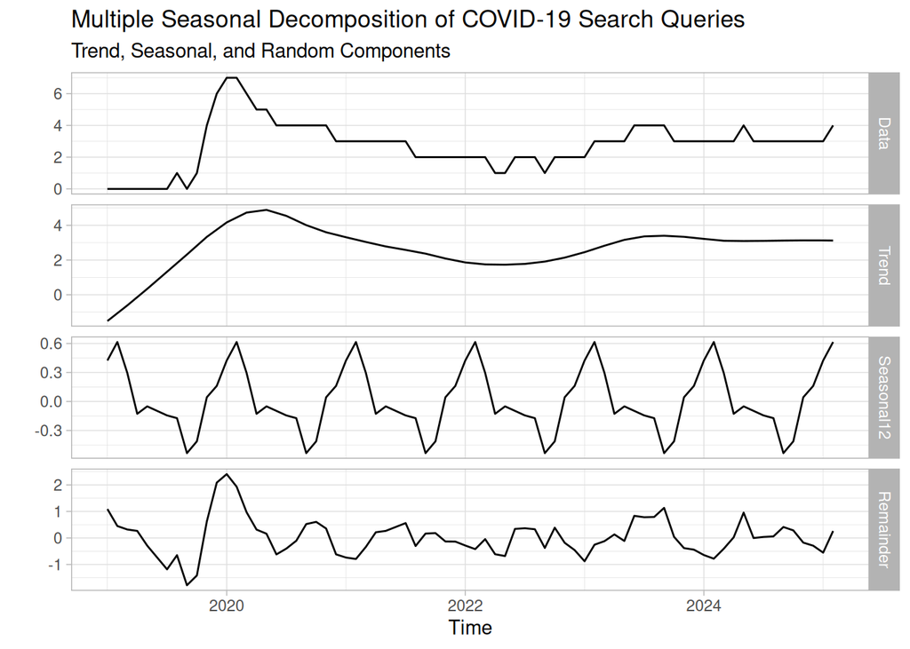

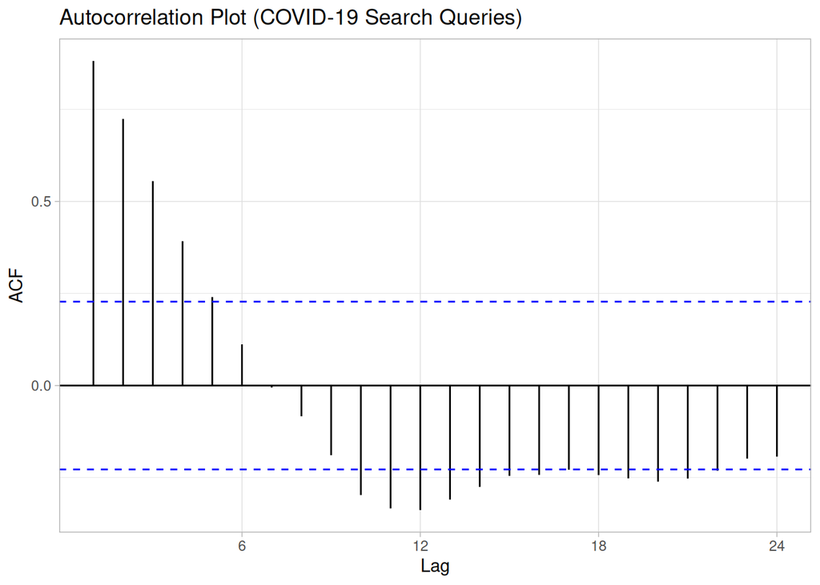

### Impact Analysis

We now assess whether specific events (like lockdown implementation) are statistically associated with changes in search patterns:

| Observations | 75 |
| --- | --- |
| Dependent variable | log(hits_num + 1) |
| Type | OLS linear regression |

| F(14,60) | 14.636 |
| --- | --- |
| R² | 0.773 |
| Adj. R² | 0.721 |

|  | Est. | S.E. | t val. | p |
| --- | --- | --- | --- | --- |
| (Intercept) | -0.074 | 0.096 | -0.769 | 0.445 |
| time | 0.055 | 0.029 | 1.886 | 0.064 |
| month2 | -0.112 | 0.071 | -1.575 | 0.120 |
| month3 | -0.225 | 0.286 | -0.788 | 0.434 |
| month4 | 0.094 | 0.168 | 0.557 | 0.579 |
| month5 | -0.019 | 0.078 | -0.239 | 0.812 |
| month6 | -0.153 | 0.165 | -0.928 | 0.357 |
| month7 | -0.199 | 0.143 | -1.386 | 0.171 |
| month8 | -0.417 | 0.137 | -3.035 | 0.004 |
| month9 | -0.463 | 0.104 | -4.459 | 0.000 |
| month10 | -0.655 | 0.161 | -4.057 | 0.000 |
| month11 | -0.521 | 0.089 | -5.844 | 0.000 |
| month12 | -0.155 | 0.084 | -1.846 | 0.070 |
| after | 1.220 | 0.391 | 3.121 | 0.003 |
| A_TimeDiff | -0.057 | 0.025 | -2.253 | 0.028 |

Standard errors: User-specified

### Practical Implications

1. **Public Health Communication**:
   - The strong immediate effect suggests high initial public interest/concern
   - The declining trend indicates a possible “pandemic fatigue” in information seeking
   - Seasonal patterns could be used to time public health messaging
2. **Policy Relevance**:
   - The gradual decline in effect (-5.7% per month) suggests a normalization of information-seeking behavior
   - Seasonal variations should be considered when interpreting search patterns
   - The high R² indicates that the model captures the major drivers of search behavior

### Limitations

- The analysis period might be too short to establish robust seasonal patterns
- The model assumes linear trends which might not fully capture the complexity of public response
- Search patterns might reflect media coverage rather than actual health concerns
- The presence of strong autocorrelation suggests possible omitted time-varying factors